# Basic analysis of U.S. political ideology by state

### Juan Andrés Cabral

We're going to delve into a dataset that captures the political leanings of various U.S. states. This dataset serves as an update to the work of Tausanovitch and Warshaw (2013). You can download the dataset from [here](https://raw.githubusercontent.com/cabraljuan/cabraljuan.github.io/main/tutorials/datasets/aip_states_ideology_v2022a.tab). The authors have computed a measure of political inclination that gauges how left-leaning (with smaller values) or right-leaning (with larger values) the residents of each U.S. state are. These calculations are rooted in surveys about specific policy preferences. By amalgamating different surveys, the authors present data spanning various U.S. presidential years for all states.

Christopher Warshaw; Chris Tausanovitch, 2022, "Subnational ideology and presidential vote estimates (v2022)", https://doi.org/10.7910/DVN/BQKU4M, Harvard Dataverse, V1 \ Tausanovitch, C., & Warshaw, C. (2013). Measuring constituent policy preferences in congress, state legislatures, and cities. The Journal of Politics, 75(2), 330-342.

```python
import pandas as pd

# Loading the dataset
data = pd.read_table("C:/Users/juanc/Downloads/aip_states_ideology_v2022a.tab")

# Displaying the first few rows of the dataset to understand its structure
data.head()
```

|  | state | presidential_year | abb | population_2020 | fips | mrp_ideology_se | mrp_ideology | irt_ideology_unweighted | self_ideology | self_ideology_se | irt_ideology_unweighted_sd | irt_ideology_unweighted_se | sample_size | survey_period | demshare_pres |
| --- | --- | --- | --- | --- | --- | --- | --- | --- | --- | --- | --- | --- | --- | --- | --- |
| 0 | Alabama | 2008 | AL | 5024279 | 1 | 0.064888 | 0.209469 | 0.214234 | 3.522654 | 0.018688 | 0.927312 | 0.016236 | 3262 | 2004-2011 | 0.391091 |
| 1 | Alabama | 2016 | AL | 5024279 | 1 | 0.036347 | 0.289731 | 0.234576 | 3.312552 | 0.021363 | 0.910887 | 0.017608 | 2676 | 2012-2016 | 0.356259 |
| 2 | Alabama | 2020 | AL | 5024279 | 1 | 0.036717 | 0.198308 | 0.208188 | 3.278374 | 0.011646 | 0.941574 | 0.009281 | 10293 | 2017-2021 | 0.370886 |
| 3 | Alaska | 2008 | AK | 733391 | 2 | 0.073391 | 0.167004 | 0.125482 | 3.297297 | 0.040185 | 1.008114 | 0.034887 | 835 | 2004-2011 | 0.389352 |
| 4 | Alaska | 2016 | AK | 733391 | 2 | 0.050497 | 0.196960 | 0.167457 | 3.225201 | 0.053345 | 1.055494 | 0.053175 | 394 | 2012-2016 | 0.416143 |

For our analysis, I'll focus on the mrp_ideology_se and mrp_ideology columns. Let's start by checking for any missing values in these two columns and then visualize their distribution.

```python
# Checking for missing values in the 'mrp_ideology_se' and 'mrp_ideology' columns
missing_values = data[["mrp_ideology_se", "mrp_ideology"]].isnull().sum()

missing_values
```

```
mrp_ideology_se    0
mrp_ideology       0
dtype: int64
```

There are no missing values in the mrp_ideology_se and mrp_ideology columns.

Next, let's visualize the distribution of the mrp_ideology column using a histogram. This will give us a sense of how the ideology scores are distributed across states.

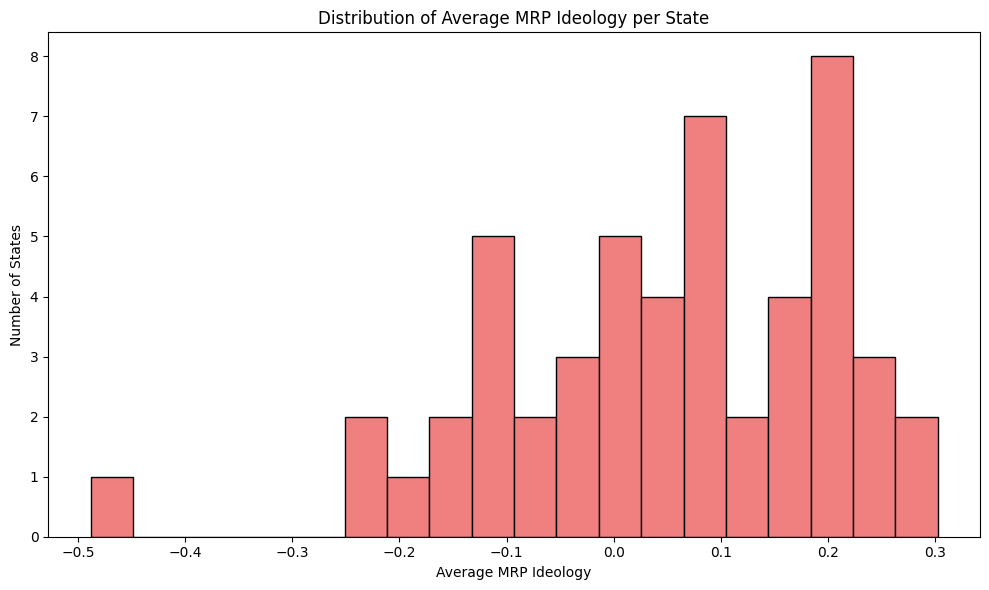

```python
# Calculating the average mrp_ideology score for each state
average_ideology_per_state = data.groupby('state')['mrp_ideology'].mean().reset_index()

# Plotting the distribution of average mrp_ideology scores across states
plt.figure(figsize=(10, 6))
plt.hist(average_ideology_per_state['mrp_ideology'], bins=20, color='lightcoral', edgecolor='black')
plt.title('Distribution of Average MRP Ideology per State')
plt.xlabel('Average MRP Ideology')
plt.ylabel('Number of States')
plt.tight_layout()
plt.show()
```

From this visualization, we can observe that most states have average ideology scores between approximately -0.1 and 0.3. This provides a consolidated view of the ideological preferences of states based on the MRP methodology.

Next, it might be interesting to see which states have the highest and lowest MRP ideology scores.

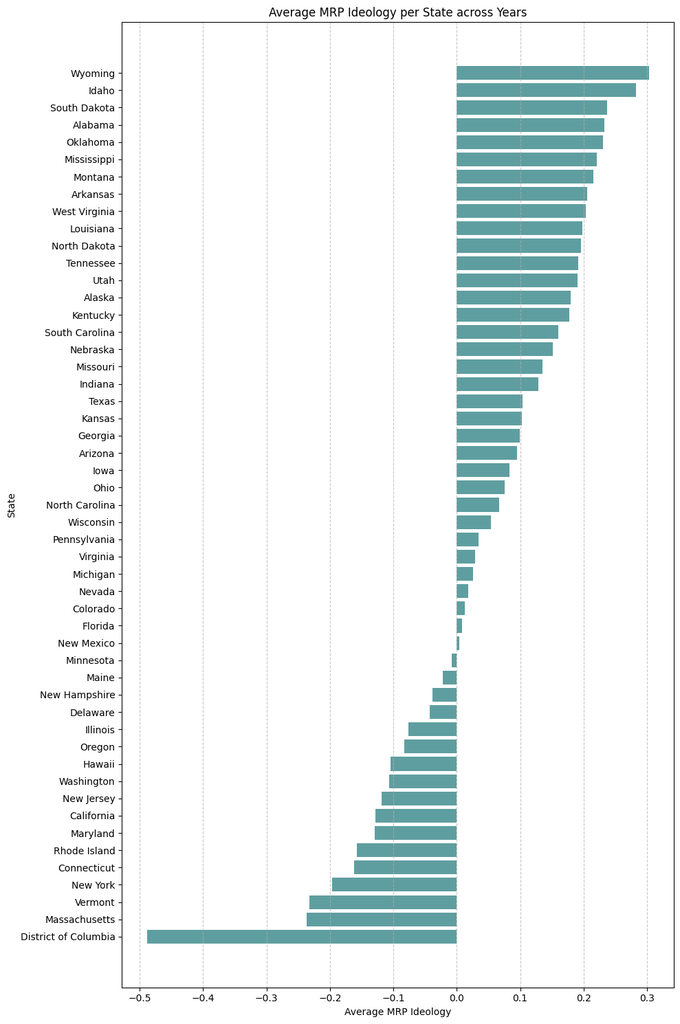

```python
# Sorting the data for better visualization
sorted_states = average_ideology_per_state.sort_values(by='mrp_ideology')

plt.figure(figsize=(10, 15))
plt.barh(sorted_states['state'], sorted_states['mrp_ideology'], color='cadetblue')
plt.xlabel('Average MRP Ideology')
plt.ylabel('State')
plt.title('Average MRP Ideology per State across Years')
plt.grid(axis='x', linestyle='--', alpha=0.7)
plt.tight_layout()
plt.show()
```

Now, we'll examine the evolution of political preferences over the years.

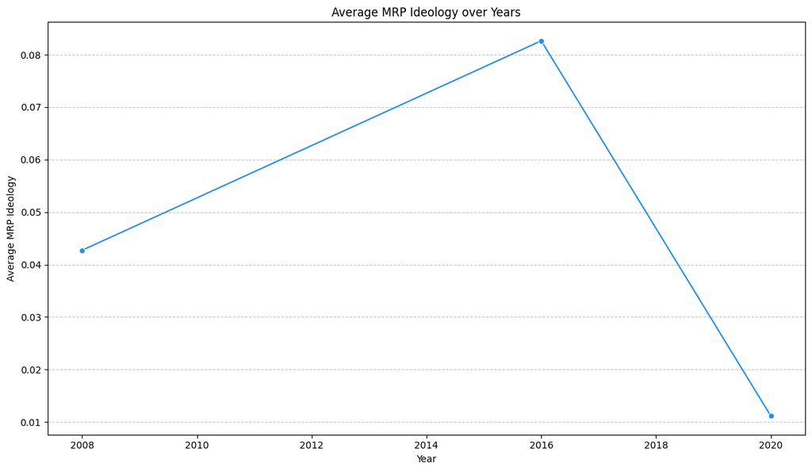

```python
import numpy as np
import seaborn as sns

# Grouping data by presidential_year and calculating the average mrp_ideology for each year
average_ideology_per_year = data.groupby('presidential_year')['mrp_ideology'].mean().reset_index()

# Plotting the time series graph
plt.figure(figsize=(12, 7))
sns.lineplot(x='presidential_year', y='mrp_ideology', data=average_ideology_per_year, marker='o', color='dodgerblue')
plt.title('Average MRP Ideology over Years')
plt.xlabel('Year')
plt.ylabel('Average MRP Ideology')
plt.grid(axis='y', linestyle='--', alpha=0.7)
plt.tight_layout()
plt.show()
```

Ideally, larger samples should have smaller standard errors. Let's analyze if this holds true for this dataset.

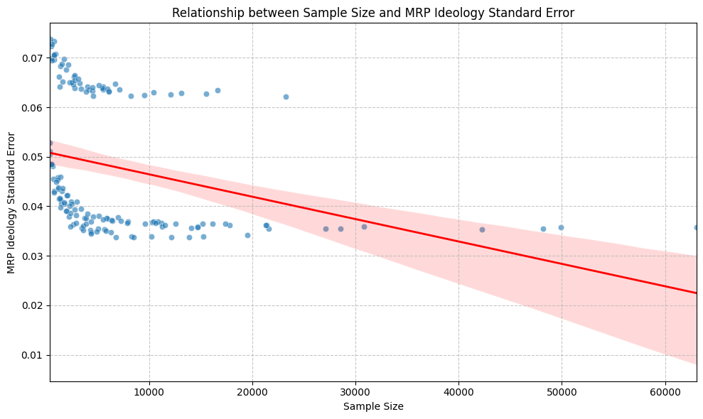

```
-0.31877779833259184
```

```python
# Scatter plot of sample_size vs. mrp_ideology_se
plt.figure(figsize=(10, 6))
sns.scatterplot(x=data['sample_size'], y=data['mrp_ideology_se'], alpha=0.6)
sns.regplot(x=data['sample_size'], y=data['mrp_ideology_se'], scatter=False, color='red', line_kws={'lw':2})
plt.title('Relationship between Sample Size and MRP Ideology Standard Error')
plt.xlabel('Sample Size')
plt.ylabel('MRP Ideology Standard Error')
plt.grid(axis='both', linestyle='--', alpha=0.7)
plt.tight_layout()
plt.show()

# Calculating the Pearson correlation coefficient
correlation_coefficient = data['sample_size'].corr(data['mrp_ideology_se'])
correlation_coefficient
```

There appears to be a negative relationship between the sample size and the MRP ideology standard error

The data on ideological leanings was derived from questions about policy preferences. Therefore, it would be intriguing to see how closely this correlates with individuals' self-reported ideology. Let's create a combined plot that merges histograms of the two variables of interest with a scatter plot to observe the relationship between them.

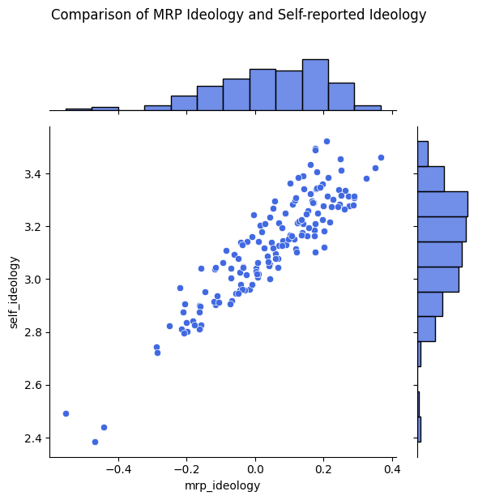

```python
# Joint plot comparing mrp_ideology and self_ideology using scatter points
sns.jointplot(x=data['mrp_ideology'], y=data['self_ideology'], color='royalblue')
plt.suptitle('Comparison of MRP Ideology and Self-reported Ideology', y=1.02)
plt.xlabel('MRP Ideology')
plt.ylabel('Self-reported Ideology')
plt.tight_layout()
plt.show()
```

In essence, the joint plot provides a visual representation of how the model's estimates (mrp_ideology) align with the self-reported ideological preferences (self_ideology). The strong alignment in the center suggests that the model generally captures the self-reported ideological preferences of respondents quite well.